> **Tip**: Welcome to the Investigate a Dataset project! You will find tips in quoted sections like this to help organize your approach to your investigation. Before submitting your project, it will be a good idea to go back through your report and remove these sections to make the presentation of your work as tidy as possible. First things first, you might want to double-click this Markdown cell and change the title so that it reflects your dataset and investigation.

# Project: Investigate a Dataset (No-show appointments dataset)

- Introduction
- Data Wrangling
- Exploratory Data Analysis
- Conclusions

## Introduction

> **Tip**: In this section of the report, provide a brief introduction to the dataset you've selected for analysis. At the end of this section, describe the questions that you plan on exploring over the course of the report. Try to build your report around the analysis of at least one dependent variable and three independent variables.

> If you haven't yet selected and downloaded your data, make sure you do that first before coming back here. If you're not sure what questions to ask right now, then make sure you familiarize yourself with the variables and the dataset context for ideas of what to explore.

```python
# Use this cell to set up import statements for all of the packages that you
#   plan to use.

# Remember to include a 'magic word' so that your visualizations are plotted
#   inline with the notebook. See this page for more:
#   http://ipython.readthedocs.io/en/stable/interactive/magics.html
import numpy as np
import pandas as pd
import matplotlib.pyplot as plt
%matplotlib inline
import seaborn as sns
```

## Data Wrangling

> **Tip**: In this section of the report, you will load in the data, check for cleanliness, and then trim and clean your dataset for analysis. Make sure that you document your steps carefully and justify your cleaning decisions.

### General Properties

```python
# Load your data and print out a few lines. Perform operations to inspect data
#   types and look for instances of missing or possibly errant data.
df = pd.read_csv('data.csv')
df.head()
```

|  | PatientId | AppointmentID | Gender | ScheduledDay | AppointmentDay | Age | Neighbourhood | Scholarship | Hipertension | Diabetes | Alcoholism | Handcap | SMS_received | No-show |
| --- | --- | --- | --- | --- | --- | --- | --- | --- | --- | --- | --- | --- | --- | --- |
| 0 | 2.987250e+13 | 5642903 | F | 2016-04-29T18:38:08Z | 2016-04-29T00:00:00Z | 62 | JARDIM DA PENHA | 0 | 1 | 0 | 0 | 0 | 0 | No |
| 1 | 5.589978e+14 | 5642503 | M | 2016-04-29T16:08:27Z | 2016-04-29T00:00:00Z | 56 | JARDIM DA PENHA | 0 | 0 | 0 | 0 | 0 | 0 | No |
| 2 | 4.262962e+12 | 5642549 | F | 2016-04-29T16:19:04Z | 2016-04-29T00:00:00Z | 62 | MATA DA PRAIA | 0 | 0 | 0 | 0 | 0 | 0 | No |
| 3 | 8.679512e+11 | 5642828 | F | 2016-04-29T17:29:31Z | 2016-04-29T00:00:00Z | 8 | PONTAL DE CAMBURI | 0 | 0 | 0 | 0 | 0 | 0 | No |
| 4 | 8.841186e+12 | 5642494 | F | 2016-04-29T16:07:23Z | 2016-04-29T00:00:00Z | 56 | JARDIM DA PENHA | 0 | 1 | 1 | 0 | 0 | 0 | No |

```python
df.shape
```

```
(110527, 14)
```

```python
df.info()
```

```
<class 'pandas.core.frame.DataFrame'>
RangeIndex: 110527 entries, 0 to 110526
Data columns (total 14 columns):
 #   Column          Non-Null Count   Dtype
---  ------          --------------   -----
 0   PatientId       110527 non-null  float64
 1   AppointmentID   110527 non-null  int64
 2   Gender          110527 non-null  object
 3   ScheduledDay    110527 non-null  object
 4   AppointmentDay  110527 non-null  object
 5   Age             110527 non-null  int64
 6   Neighbourhood   110527 non-null  object
 7   Scholarship     110527 non-null  int64
 8   Hipertension    110527 non-null  int64
 9   Diabetes        110527 non-null  int64
 10  Alcoholism      110527 non-null  int64
 11  Handcap         110527 non-null  int64
 12  SMS_received    110527 non-null  int64
 13  No-show         110527 non-null  object
dtypes: float64(1), int64(8), object(5)
memory usage: 11.8+ MB
```

- ScheduledDay and AppointmentDay shoud be in datetime not string(object)
- we don't need PatientId and AppointmentID so we will drob it

```python
df.duplicated().sum()
```

```
0
```

Great ! There is no dublicated value in dataset

```python
#show uniqe values in some columns
for i in df.columns[np.r_[2, 5:14]]:
  print('The uniqe values of ' + str(i) + ' is ' + str(np.sort(df[i].unique())))
  print('-------------------------------')
```

```
The uniqe values of Gender is ['F' 'M']
-------------------------------
The uniqe values of Age is [ -1   0   1   2   3   4   5   6   7   8   9  10  11  12  13  14  15  16
  17  18  19  20  21  22  23  24  25  26  27  28  29  30  31  32  33  34
  35  36  37  38  39  40  41  42  43  44  45  46  47  48  49  50  51  52
  53  54  55  56  57  58  59  60  61  62  63  64  65  66  67  68  69  70
  71  72  73  74  75  76  77  78  79  80  81  82  83  84  85  86  87  88
  89  90  91  92  93  94  95  96  97  98  99 100 102 115]
-------------------------------
The uniqe values of Neighbourhood is ['AEROPORTO' 'ANDORINHAS' 'ANTÔNIO HONÓRIO' 'ARIOVALDO FAVALESSA'
 'BARRO VERMELHO' 'BELA VISTA' 'BENTO FERREIRA' 'BOA VISTA' 'BONFIM'
 'CARATOÍRA' 'CENTRO' 'COMDUSA' 'CONQUISTA' 'CONSOLAÇÃO' 'CRUZAMENTO'
 'DA PENHA' 'DE LOURDES' 'DO CABRAL' 'DO MOSCOSO' 'DO QUADRO'
 'ENSEADA DO SUÁ' 'ESTRELINHA' 'FONTE GRANDE' 'FORTE SÃO JOÃO' 'FRADINHOS'
 'GOIABEIRAS' 'GRANDE VITÓRIA' 'GURIGICA' 'HORTO' 'ILHA DAS CAIEIRAS'
 'ILHA DE SANTA MARIA' 'ILHA DO BOI' 'ILHA DO FRADE' 'ILHA DO PRÍNCIPE'
 'ILHAS OCEÂNICAS DE TRINDADE' 'INHANGUETÁ' 'ITARARÉ' 'JABOUR'
 'JARDIM CAMBURI' 'JARDIM DA PENHA' 'JESUS DE NAZARETH' 'JOANA D´ARC'
 'JUCUTUQUARA' 'MARIA ORTIZ' 'MARUÍPE' 'MATA DA PRAIA' 'MONTE BELO'
 'MORADA DE CAMBURI' 'MÁRIO CYPRESTE' 'NAZARETH' 'NOVA PALESTINA'
 'PARQUE INDUSTRIAL' 'PARQUE MOSCOSO' 'PIEDADE' 'PONTAL DE CAMBURI'
 'PRAIA DO CANTO' 'PRAIA DO SUÁ' 'REDENÇÃO' 'REPÚBLICA' 'RESISTÊNCIA'
 'ROMÃO' 'SANTA CECÍLIA' 'SANTA CLARA' 'SANTA HELENA' 'SANTA LUÍZA'
 'SANTA LÚCIA' 'SANTA MARTHA' 'SANTA TEREZA' 'SANTO ANDRÉ' 'SANTO ANTÔNIO'
 'SANTOS DUMONT' 'SANTOS REIS' 'SEGURANÇA DO LAR' 'SOLON BORGES'
 'SÃO BENEDITO' 'SÃO CRISTÓVÃO' 'SÃO JOSÉ' 'SÃO PEDRO' 'TABUAZEIRO'
 'UNIVERSITÁRIO' 'VILA RUBIM']
-------------------------------
The uniqe values of Scholarship is [0 1]
-------------------------------
The uniqe values of Hipertension is [0 1]
-------------------------------
The uniqe values of Diabetes is [0 1]
-------------------------------
The uniqe values of Alcoholism is [0 1]
-------------------------------
The uniqe values of Handcap is [0 1 2 3 4]
-------------------------------
The uniqe values of SMS_received is [0 1]
-------------------------------
The uniqe values of No-show is ['No' 'Yes']
-------------------------------
```

There is no human with age = -1 so i will drop it

> **Tip**: You should *not* perform too many operations in each cell. Create cells freely to explore your data. One option that you can take with this project is to do a lot of explorations in an initial notebook. These don't have to be organized, but make sure you use enough comments to understand the purpose of each code cell. Then, after you're done with your analysis, create a duplicate notebook where you will trim the excess and organize your steps so that you have a flowing, cohesive report.

> **Tip**: Make sure that you keep your reader informed on the steps that you are taking in your investigation. Follow every code cell, or every set of related code cells, with a markdown cell to describe to the reader what was found in the preceding cell(s). Try to make it so that the reader can then understand what they will be seeing in the following cell(s).

```python
# After discussing the structure of the data and any problems that need to be
#   cleaned, perform those cleaning steps in the second part of this section.
```

```python
#Changing datatypes of ScheduledDay and AppointmentDay to datetime datatype
to_date = ['ScheduledDay'	,'AppointmentDay']
for i in to_date:
  df[i] = pd.to_datetime(df[i]).dt.date.astype('datetime64[ns]')
```

```python
#Droping PatientId and AppointmentID
df.drop(columns=['PatientId','AppointmentID'] , inplace = True)
```

```python
df = df[(df['Age'] >=0) &(df['Age'] <=100)]
```

```python
df.info()
```

```
<class 'pandas.core.frame.DataFrame'>
Int64Index: 110519 entries, 0 to 110526
Data columns (total 12 columns):
 #   Column          Non-Null Count   Dtype
---  ------          --------------   -----
 0   Gender          110519 non-null  object
 1   ScheduledDay    110519 non-null  datetime64[ns]
 2   AppointmentDay  110519 non-null  datetime64[ns]
 3   Age             110519 non-null  int64
 4   Neighbourhood   110519 non-null  object
 5   Scholarship     110519 non-null  int64
 6   Hipertension    110519 non-null  int64
 7   Diabetes        110519 non-null  int64
 8   Alcoholism      110519 non-null  int64
 9   Handcap         110519 non-null  int64
 10  SMS_received    110519 non-null  int64
 11  No-show         110519 non-null  object
dtypes: datetime64[ns](2), int64(7), object(3)
memory usage: 11.0+ MB
```

```python
df.head()
```

|  | Gender | ScheduledDay | AppointmentDay | Age | Neighbourhood | Scholarship | Hipertension | Diabetes | Alcoholism | Handcap | SMS_received | No-show |
| --- | --- | --- | --- | --- | --- | --- | --- | --- | --- | --- | --- | --- |
| 0 | F | 2016-04-29 | 2016-04-29 | 62 | JARDIM DA PENHA | 0 | 1 | 0 | 0 | 0 | 0 | No |
| 1 | M | 2016-04-29 | 2016-04-29 | 56 | JARDIM DA PENHA | 0 | 0 | 0 | 0 | 0 | 0 | No |
| 2 | F | 2016-04-29 | 2016-04-29 | 62 | MATA DA PRAIA | 0 | 0 | 0 | 0 | 0 | 0 | No |
| 3 | F | 2016-04-29 | 2016-04-29 | 8 | PONTAL DE CAMBURI | 0 | 0 | 0 | 0 | 0 | 0 | No |
| 4 | F | 2016-04-29 | 2016-04-29 | 56 | JARDIM DA PENHA | 0 | 1 | 1 | 0 | 0 | 0 | No |

Good -_* Our data is now ready to play with it

## Exploratory Data Analysis

> **Tip**: Now that you've trimmed and cleaned your data, you're ready to move on to exploration. Compute statistics and create visualizations with the goal of addressing the research questions that you posed in the Introduction section. It is recommended that you be systematic with your approach. Look at one variable at a time, and then follow it up by looking at relationships between variables.

### Research Question 1 ( What is the percentage of no-show at the specified time?)

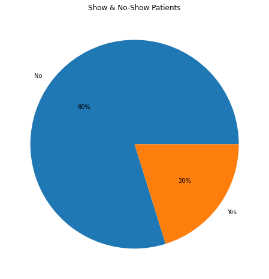

```python
# Use this, and more code cells, to explore your data. Don't forget to add
#   Markdown cells to document your observations and findings.
plt.figure(figsize=(8,8))
_ =plt.pie(df['No-show'].value_counts() , labels=df['No-show'].value_counts().index, autopct='%1.0f%%' );
plt.title('Show & No-Show Patients')
plt.show()
```

Then 20% of patients not attendings in their time

### Research Question 2 (Finding Waiting Time and finding the correlation between it and target(No-show)!)

```python
# Continue to explore the data to address your additional research
#   questions. Add more headers as needed if you have more questions to
#   investigate.
df['waitingTime'] = df['AppointmentDay'] - df['ScheduledDay']
df['waitingTime'] = df['waitingTime'].dt.days
```

```python
df['AppointmentDayName'] = df['AppointmentDay'].dt.day_name()
df['ScheduledDayName'] = df['ScheduledDay'].dt.day_name()
```

```python
df = df[df['waitingTime']>=0]
```

```python
df.head()
```

|  | Gender | ScheduledDay | AppointmentDay | Age | Neighbourhood | Scholarship | Hipertension | Diabetes | Alcoholism | Handcap | SMS_received | No-show | waitingTime | AppointmentDayName | ScheduledDayName |
| --- | --- | --- | --- | --- | --- | --- | --- | --- | --- | --- | --- | --- | --- | --- | --- |
| 0 | F | 2016-04-29 | 2016-04-29 | 62 | JARDIM DA PENHA | 0 | 1 | 0 | 0 | 0 | 0 | No | 0 | Friday | Friday |
| 1 | M | 2016-04-29 | 2016-04-29 | 56 | JARDIM DA PENHA | 0 | 0 | 0 | 0 | 0 | 0 | No | 0 | Friday | Friday |
| 2 | F | 2016-04-29 | 2016-04-29 | 62 | MATA DA PRAIA | 0 | 0 | 0 | 0 | 0 | 0 | No | 0 | Friday | Friday |
| 3 | F | 2016-04-29 | 2016-04-29 | 8 | PONTAL DE CAMBURI | 0 | 0 | 0 | 0 | 0 | 0 | No | 0 | Friday | Friday |
| 4 | F | 2016-04-29 | 2016-04-29 | 56 | JARDIM DA PENHA | 0 | 1 | 1 | 0 | 0 | 0 | No | 0 | Friday | Friday |

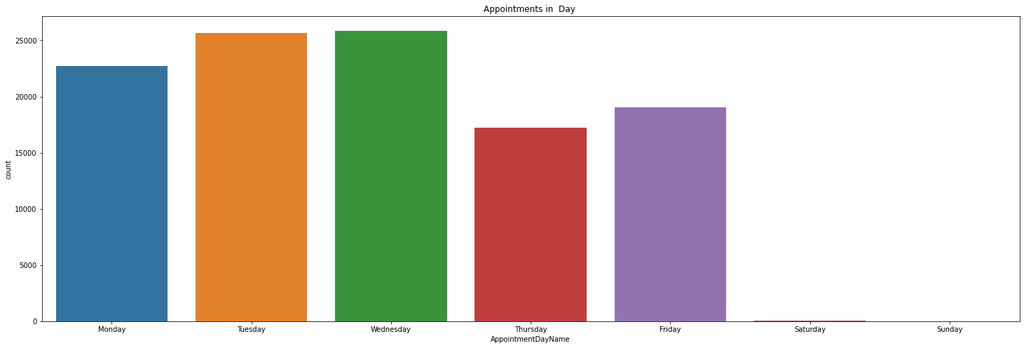

```python
week_key = ['Monday','Tuesday','Wednesday','Thursday','Friday','Saturday','Sunday']

plt.figure(figsize=(25,8))
_ = sns.countplot(x=df['AppointmentDayName'] , order=week_key,data = df)
plt.title('Appointments in  Day ')
plt.show()
```

There are no appointments on Sunday and very less appointments on Saturday

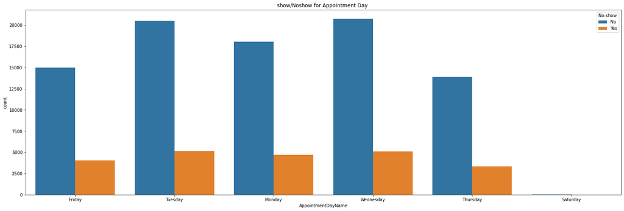

```python
plt.figure(figsize=(25,8))
_ = sns.countplot(x=df['AppointmentDayName'] , hue = df['No-show'] ,data = df)
plt.title('show/Noshow for Appointment Day ')
plt.show()
```

```python
(df[df['No-show'] =='No'].groupby('AppointmentDayName').size() / df.groupby('AppointmentDayName').size()) *100
```

```
AppointmentDayName
Friday       78.772742
Monday       79.358020
Saturday     76.923077
Thursday     80.658818
Tuesday      79.911846
Wednesday    80.313926
dtype: float64
```

The percentage of attendance in all days are close But on Saturday's the percentage of visits is less

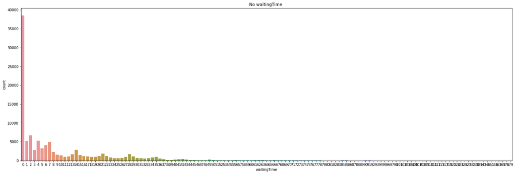

```python
plt.figure(figsize=(25,8))
_ = sns.countplot(x=df['waitingTime'] ,data = df)
plt.title('No waitingTime ')
plt.show()
```

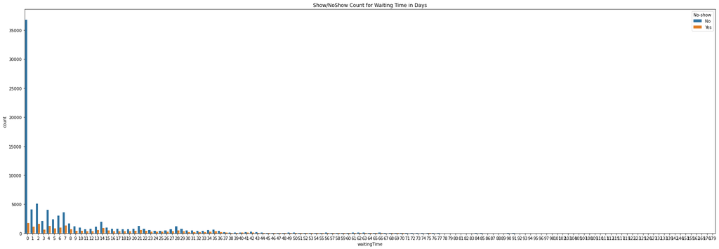

```python
plt.figure(figsize=(30,10))
ax = sns.countplot(x=df['waitingTime'], hue=df['No-show'],data = df)
ax.set_title("Show/NoShow Count for Waiting Time in Days")
plt.show()
```

```python
(df[df['No-show'] =='No'].groupby('waitingTime').size() / df.groupby('waitingTime').size()) *100
```

```
waitingTime
0      95.352697
1      78.649530
2      76.174896
3      76.526508
4      76.729679
         ...
155    40.000000
162    81.818182
169    87.500000
176    62.500000
179    80.000000
Length: 129, dtype: float64
```

95% of the patients who have booked their appointments on the same day and attend in their appointments .for that this is a good feture

# Any age group is more present at its appointment ?

```python
import plotly.express as px
fig = px.box(df, y="Age",title='Distribution Of Age')
fig.show()
```

[interactive chart not shown]

```python
df_yes = df[df['No-show']=='Yes'].copy()
df_no = df[df['No-show']=='No'].copy()
```

```python
fig = px.box(df_yes, y="Age" ,title='Distribution Of Age when No-show = yes')
fig.show()
```

[interactive chart not shown]

```python
fig = px.box(df_no, y="Age" ,title='Distribution Of Age when No-show = No')
fig.show()
```

[interactive chart not shown]

From the above BoxPlot we can see that:

1. Median of patients ages that did not show up to their appointment is 33 and ranging between 16:51
2. Median of patients ages that showed up to their appointment is 38 and ranging between 18:56
3. It looks like younger people no-show more than older ones.

```python
df.head()
```

|  | Gender | ScheduledDay | AppointmentDay | Age | Neighbourhood | Scholarship | Hipertension | Diabetes | Alcoholism | Handcap | SMS_received | No-show | waitingTime | AppointmentDayName | ScheduledDayName |
| --- | --- | --- | --- | --- | --- | --- | --- | --- | --- | --- | --- | --- | --- | --- | --- |
| 0 | F | 2016-04-29 | 2016-04-29 | 62 | JARDIM DA PENHA | 0 | 1 | 0 | 0 | 0 | 0 | No | 0 | Friday | Friday |
| 1 | M | 2016-04-29 | 2016-04-29 | 56 | JARDIM DA PENHA | 0 | 0 | 0 | 0 | 0 | 0 | No | 0 | Friday | Friday |
| 2 | F | 2016-04-29 | 2016-04-29 | 62 | MATA DA PRAIA | 0 | 0 | 0 | 0 | 0 | 0 | No | 0 | Friday | Friday |
| 3 | F | 2016-04-29 | 2016-04-29 | 8 | PONTAL DE CAMBURI | 0 | 0 | 0 | 0 | 0 | 0 | No | 0 | Friday | Friday |
| 4 | F | 2016-04-29 | 2016-04-29 | 56 | JARDIM DA PENHA | 0 | 1 | 1 | 0 | 0 | 0 | No | 0 | Friday | Friday |

# Does the gender of patient affect attendance?

```python
df['Gender'].value_counts()
```

```
F    71829
M    38685
Name: Gender, dtype: int64
```

```python
(df['Gender'].value_counts()) / df.shape[0]
```

```
F    0.649954
M    0.350046
Name: Gender, dtype: float64
```

```python
df.groupby('Gender')['No-show'].value_counts()
```

```
Gender  No-show
F       No         57241
        Yes        14588
M       No         30962
        Yes         7723
Name: No-show, dtype: int64
```

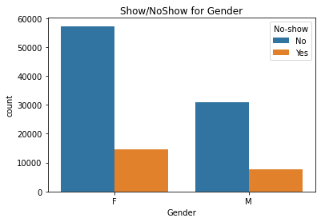

```python
sns.countplot(x =df['Gender'] , hue= df['No-show'] , data=df)
plt.title("Show/NoShow for "+str('Gender'))
plt.show()
```

From above we can say that Female show-up more than Male. May be because we have more data of females

# Is Neighbourhood column is important to determine show-up or no-show?

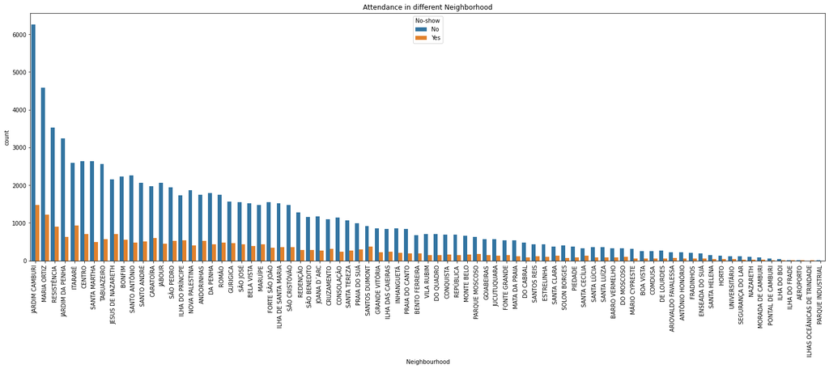

```python
plt.figure(figsize=(25,8))
sns.countplot(x =df['Neighbourhood'] , hue= df['No-show'] , data=df, order=df.Neighbourhood.value_counts().index)
plt.title('Attendance in different Neighborhood')
plt.xticks(rotation=90)
plt.show()
```

- From above the top 4 hosbitals that show up are ['JARDIM CAMBURI', 'MARIA ORTIZ', 'RESISTÊNCIA', 'JARDIM DA PENHA']
- Neighbourhood is important feature

# Scholarship

```python
df['Scholarship'].value_counts()
```

```
0    99653
1    10861
Name: Scholarship, dtype: int64
```

```python
(df['Scholarship'].value_counts() / df.shape[0])*100
```

```
0    90.172286
1     9.827714
Name: Scholarship, dtype: float64
```

- 90% of patients not have Scholarship

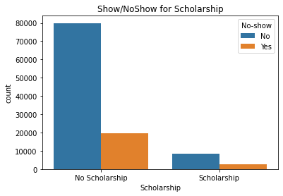

```python
ax = sns.countplot(x=df.Scholarship, hue=df['No-show'], data=df)
ax.set_title("Show/NoShow for Scholarship")
x_ticks_labels=['No Scholarship', 'Scholarship']
ax.set_xticklabels(x_ticks_labels)
plt.show()
```

```python
#Percentage for Scholarship
(df[df['No-show'] =='No'].groupby('Scholarship').size() / df.groupby('Scholarship').size()) *100
```

```
Scholarship
0    80.198288
1    76.263696
dtype: float64
```

- from above we can say that 80% of patients without Scholarship and 76% with Scholarship are show up
- Scholarship feture can help us in determining if a patient will attend in his ppointment.

# Will the type of disease affect on attendance?

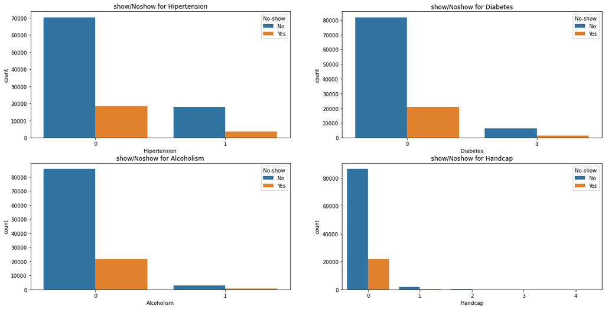

```python
plt.figure(figsize=(20,10));
plt.subplot(2,2,1)
sns.countplot(df['Hipertension'],hue=df['No-show'])
plt.title('show/Noshow for Hipertension')
plt.subplot(2,2,2)
sns.countplot(df['Diabetes'],hue=df['No-show'])
plt.title('show/Noshow for Diabetes')
plt.subplot(2,2,3)
sns.countplot(df['Alcoholism'],hue=df['No-show'])
plt.title('show/Noshow for Alcoholism')
plt.subplot(2,2,4)
sns.countplot(df['Handcap'],hue=df['No-show'])
plt.title('show/Noshow for Handcap')
```

```python
df.info()
```

```
<class 'pandas.core.frame.DataFrame'>
Int64Index: 110514 entries, 0 to 110526
Data columns (total 15 columns):
 #   Column              Non-Null Count   Dtype
---  ------              --------------   -----
 0   Gender              110514 non-null  object
 1   ScheduledDay        110514 non-null  datetime64[ns]
 2   AppointmentDay      110514 non-null  datetime64[ns]
 3   Age                 110514 non-null  int64
 4   Neighbourhood       110514 non-null  object
 5   Scholarship         110514 non-null  int64
 6   Hipertension        110514 non-null  int64
 7   Diabetes            110514 non-null  int64
 8   Alcoholism          110514 non-null  int64
 9   Handcap             110514 non-null  int64
 10  SMS_received        110514 non-null  int64
 11  No-show             110514 non-null  object
 12  waitingTime         110514 non-null  int64
 13  AppointmentDayName  110514 non-null  object
 14  ScheduledDayName    110514 non-null  object
dtypes: datetime64[ns](2), int64(8), object(5)
memory usage: 18.5+ MB
```

```python
#Percentage for ['Hipertension','Diabetes','Alcoholism' , 'Handcap']
columns = ['Hipertension','Diabetes','Alcoholism' , 'Handcap']
for i in columns:
  print('Percentage for ' + i )
  print((df[df['No-show'] =='No'].groupby(i).size() / df.groupby(i).size()) *100 )
  print('-'*20)
```

```
Percentage for Hipertension
Hipertension
0    79.102509
1    82.697248
dtype: float64
--------------------
Percentage for Diabetes
Diabetes
0    79.642394
1    81.996727
dtype: float64
--------------------
Percentage for Alcoholism
Alcoholism
0    79.810366
1    79.851190
dtype: float64
--------------------
Percentage for Handcap
Handcap
0    79.766160
1    82.269155
2    79.781421
3    76.923077
4    66.666667
dtype: float64
--------------------
```

From above we can say that

- 83% of patients with Hipertension are show up -- good feture
- 82% of patients with Diabetes are show up -- good feture
- patients with or without Alcoholism have the same Percentage , For that this feture will not help us determining if a patient will attend in his ppointment.

# SMS_received

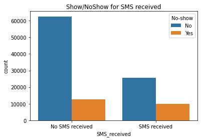

```python
ax = sns.countplot(x=df['SMS_received'], hue=df['No-show'], data=df)
ax.set_title("Show/NoShow for SMS received")
x_ticks_labels=['No SMS received', 'SMS received']
ax.set_xticklabels(x_ticks_labels)
plt.show()
```

```python
( df[df['No-show'] == 'No'].groupby(['SMS_received']).size()/df.groupby(['SMS_received']).size()) * 100
```

```
SMS_received
0    83.304679
1    72.424678
dtype: float64
```

Surprise ! 83% of patients with no SMS received attend in their appointments.This is a good feture in determining if a patient will attend in his appointment. (Although realistic, people who receive messages have more to come to their appointments than others)

## Conclusions

> **Tip**: Finally, summarize your findings and the results that have been performed. Make sure that you are clear with regards to the limitations of your exploration. If you haven't done any statistical tests, do not imply any statistical conclusions. And make sure you avoid implying causation from correlation!